# Data Science Job salaries

Data science job salries encompassing the experience level,employment time,work year,salary,salary in dollars,remote ration,company location,employee's residence etc.

## IMPORTS

```python
import pandas as pd
import opendatasets as od
```

```python
datasets_url= 'https://www.kaggle.com/datasets/ruchi798/data-science-job-salaries'
od.download(datasets_url)
```

```
Skipping, found downloaded files in ".\data-science-job-salaries" (use force=True to force download)
```

```python
data_dir=".\data-science-job-salaries"
```

```python
import os
os.listdir(data_dir)
```

```
['ds_salaries.csv']
```

```python
ds_job_salary_df= pd.read_csv("data-science-job-salaries/ds_salaries.csv")
ds_job_salary_df
os.getcwd()
```

```
'c:\\Users\\OLUWASORE\\Documents\\Data Analytics'
```

```python
ds_job_salary_df= pd.read_csv("data-science-job-salaries/ds_salaries.csv")
ds_job_salary_df
```

|  | Unnamed: 0 | work_year | experience_level | employment_type | job_title | salary | salary_currency | salary_in_usd | employee_residence | remote_ratio | company_location | company_size |
| --- | --- | --- | --- | --- | --- | --- | --- | --- | --- | --- | --- | --- |
| 0 | 0 | 2020 | MI | FT | Data Scientist | 70000 | EUR | 79833 | DE | 0 | DE | L |
| 1 | 1 | 2020 | SE | FT | Machine Learning Scientist | 260000 | USD | 260000 | JP | 0 | JP | S |
| 2 | 2 | 2020 | SE | FT | Big Data Engineer | 85000 | GBP | 109024 | GB | 50 | GB | M |
| 3 | 3 | 2020 | MI | FT | Product Data Analyst | 20000 | USD | 20000 | HN | 0 | HN | S |
| 4 | 4 | 2020 | SE | FT | Machine Learning Engineer | 150000 | USD | 150000 | US | 50 | US | L |
| ... | ... | ... | ... | ... | ... | ... | ... | ... | ... | ... | ... | ... |
| 602 | 602 | 2022 | SE | FT | Data Engineer | 154000 | USD | 154000 | US | 100 | US | M |
| 603 | 603 | 2022 | SE | FT | Data Engineer | 126000 | USD | 126000 | US | 100 | US | M |
| 604 | 604 | 2022 | SE | FT | Data Analyst | 129000 | USD | 129000 | US | 0 | US | M |
| 605 | 605 | 2022 | SE | FT | Data Analyst | 150000 | USD | 150000 | US | 100 | US | M |
| 606 | 606 | 2022 | MI | FT | AI Scientist | 200000 | USD | 200000 | IN | 100 | US | L |

607 rows × 12 columns

## DATA CLEANING

```python
ds_job_salary_df.shape
```

```
(607, 12)
```

```python
ds_job_salary_df.columns
```

```
Index(['Unnamed: 0', 'work_year', 'experience_level', 'employment_type',
       'job_title', 'salary', 'salary_currency', 'salary_in_usd',
       'employee_residence', 'remote_ratio', 'company_location',
       'company_size'],
      dtype='object')
```

```python
ds_job_sal_df=ds_job_salary_df.copy()
```

```python
ds_job_sal_df
```

|  | Unnamed: 0 | work_year | experience_level | employment_type | job_title | salary | salary_currency | salary_in_usd | employee_residence | remote_ratio | company_location | company_size |
| --- | --- | --- | --- | --- | --- | --- | --- | --- | --- | --- | --- | --- |
| 0 | 0 | 2020 | MI | FT | Data Scientist | 70000 | EUR | 79833 | DE | 0 | DE | L |
| 1 | 1 | 2020 | SE | FT | Machine Learning Scientist | 260000 | USD | 260000 | JP | 0 | JP | S |
| 2 | 2 | 2020 | SE | FT | Big Data Engineer | 85000 | GBP | 109024 | GB | 50 | GB | M |
| 3 | 3 | 2020 | MI | FT | Product Data Analyst | 20000 | USD | 20000 | HN | 0 | HN | S |
| 4 | 4 | 2020 | SE | FT | Machine Learning Engineer | 150000 | USD | 150000 | US | 50 | US | L |
| ... | ... | ... | ... | ... | ... | ... | ... | ... | ... | ... | ... | ... |
| 602 | 602 | 2022 | SE | FT | Data Engineer | 154000 | USD | 154000 | US | 100 | US | M |
| 603 | 603 | 2022 | SE | FT | Data Engineer | 126000 | USD | 126000 | US | 100 | US | M |
| 604 | 604 | 2022 | SE | FT | Data Analyst | 129000 | USD | 129000 | US | 0 | US | M |
| 605 | 605 | 2022 | SE | FT | Data Analyst | 150000 | USD | 150000 | US | 100 | US | M |
| 606 | 606 | 2022 | MI | FT | AI Scientist | 200000 | USD | 200000 | IN | 100 | US | L |

607 rows × 12 columns

```python
ds_job_sal_df.info()
```

```
<class 'pandas.core.frame.DataFrame'>
RangeIndex: 607 entries, 0 to 606
Data columns (total 12 columns):
 #   Column              Non-Null Count  Dtype
---  ------              --------------  -----
 0   Unnamed: 0          607 non-null    int64
 1   work_year           607 non-null    int64
 2   experience_level    607 non-null    object
 3   employment_type     607 non-null    object
 4   job_title           607 non-null    object
 5   salary              607 non-null    int64
 6   salary_currency     607 non-null    object
 7   salary_in_usd       607 non-null    int64
 8   employee_residence  607 non-null    object
 9   remote_ratio        607 non-null    int64
 10  company_location    607 non-null    object
 11  company_size        607 non-null    object
dtypes: int64(5), object(7)
memory usage: 57.0+ KB
```

```python
ds_job_sal_df.drop('Unnamed: 0',axis=1,inplace=True)
```

```python
ds_job_sal_df.info()
```

```
<class 'pandas.core.frame.DataFrame'>
RangeIndex: 607 entries, 0 to 606
Data columns (total 11 columns):
 #   Column              Non-Null Count  Dtype
---  ------              --------------  -----
 0   work_year           607 non-null    int64
 1   experience_level    607 non-null    object
 2   employment_type     607 non-null    object
 3   job_title           607 non-null    object
 4   salary              607 non-null    int64
 5   salary_currency     607 non-null    object
 6   salary_in_usd       607 non-null    int64
 7   employee_residence  607 non-null    object
 8   remote_ratio        607 non-null    int64
 9   company_location    607 non-null    object
 10  company_size        607 non-null    object
dtypes: int64(4), object(7)
memory usage: 52.3+ KB
```

```python
ds_job_sal_df.isnull().sum()
```

```
work_year             0
experience_level      0
employment_type       0
job_title             0
salary                0
salary_currency       0
salary_in_usd         0
employee_residence    0
remote_ratio          0
company_location      0
company_size          0
dtype: int64
```

```python
ds_job_sal_df.salary
```

```
0       70000
1      260000
2       85000
3       20000
4      150000
        ...
602    154000
603    126000
604    129000
605    150000
606    200000
Name: salary, Length: 607, dtype: int64
```

```python
ds_job_sal_df.remote_ratio
```

```
0        0
1        0
2       50
3        0
4       50
      ...
602    100
603    100
604      0
605    100
606    100
Name: remote_ratio, Length: 607, dtype: int64
```

```python
ds_job_sal_df.company_location.nunique()
```

```
50
```

```python
ds_job_sal_df.company_location.value_counts()
```

```
US    355
GB     47
CA     30
DE     28
IN     24
FR     15
ES     14
GR     11
JP      6
NL      4
AT      4
PT      4
PL      4
LU      3
PK      3
BR      3
AE      3
MX      3
AU      3
TR      3
DK      3
IT      2
CZ      2
SI      2
RU      2
CH      2
NG      2
CN      2
BE      2
VN      1
EE      1
AS      1
DZ      1
MY      1
MD      1
KE      1
SG      1
CO      1
IR      1
CL      1
MT      1
IL      1
UA      1
IQ      1
RO      1
HR      1
NZ      1
HU      1
HN      1
IE      1
Name: company_location, dtype: int64
```

```python
ds_job_sal_df.salary_currency.unique()
```

```
array(['EUR', 'USD', 'GBP', 'HUF', 'INR', 'JPY', 'CNY', 'MXN', 'CAD',
       'DKK', 'PLN', 'SGD', 'CLP', 'BRL', 'TRY', 'AUD', 'CHF'],
      dtype=object)
```

```python
ds_job_sal_df.salary_currency.nunique()
```

```
17
```

```python
ds_job_sal_df.drop('salary',axis=1,inplace=True)
```

```python
ds_job_sal_df.work_year.value_counts()
```

```
2022    318
2021    217
2020     72
Name: work_year, dtype: int64
```

```python
ds_job_sal_df.company_size.value_counts()
```

```
M    326
L    198
S     83
Name: company_size, dtype: int64
```

## DATA MANIPULATION WITH VISUALIZATION

```python
ds_job_sal_df.describe()
```

|  | work_year | salary_in_usd | remote_ratio |
| --- | --- | --- | --- |
| count | 607.000000 | 607.000000 | 607.00000 |
| mean | 2021.405272 | 112297.869852 | 70.92257 |
| std | 0.692133 | 70957.259411 | 40.70913 |
| min | 2020.000000 | 2859.000000 | 0.00000 |
| 25% | 2021.000000 | 62726.000000 | 50.00000 |
| 50% | 2022.000000 | 101570.000000 | 100.00000 |
| 75% | 2022.000000 | 150000.000000 | 100.00000 |
| max | 2022.000000 | 600000.000000 | 100.00000 |

```python
import seaborn as sns
import matplotlib
import matplotlib.pyplot as plt
%matplotlib inline
```

```python
sns.set_style('darkgrid')
matplotlib.rcParams['font.size'] = 14
matplotlib.rcParams['figure.figsize'] = (9, 5)
matplotlib.rcParams['figure.facecolor'] = '#00000000'
```

```python
salary_currency=ds_job_sal_df.salary_currency.value_counts()
salary_currency_percentage=salary_currency*100/ds_job_sal_df.salary_currency.count()
salary_currency_percentage
```

```
USD    65.568369
EUR    15.650741
GBP     7.248764
INR     4.448105
CAD     2.965404
JPY     0.494234
PLN     0.494234
TRY     0.494234
CNY     0.329489
MXN     0.329489
HUF     0.329489
DKK     0.329489
SGD     0.329489
BRL     0.329489
AUD     0.329489
CLP     0.164745
CHF     0.164745
Name: salary_currency, dtype: float64
```

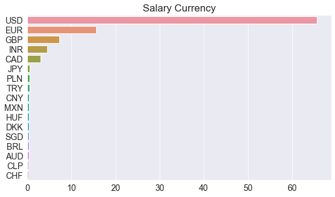

```python
sns.barplot(x=salary_currency_percentage,y=salary_currency_percentage.index)
plt.title('Salary Currency')
plt.ylabel(None);
plt.xlabel(None);
```

66% receives their salaries normally in USD,which shows USD is a preffered choice for global Exchange in data science which makes it encouraging to work internationally without having currency issues and salary marginalisation.

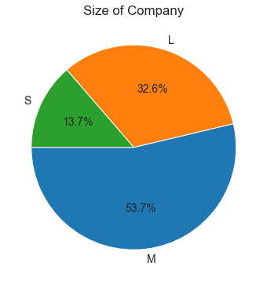

```python
Company_size=ds_job_sal_df.company_size.value_counts()
#visualization

plt.figure(figsize=(12,6))
plt.title('Size of Company')
plt.pie(Company_size,labels=Company_size.index,autopct='%1.1f%%',startangle=180,);
```

More than half of data science companies are Medium.It is noticed the Medium companies dominates the Data science world followed by a large margin whiles small companies(start ups) accross the world being little which shows enough capital is needed to run the Companies effectively.

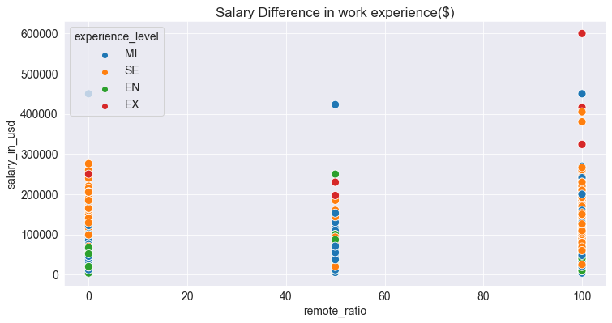

```python
plt.figure(figsize=(12, 6))
plt.title('Salary Difference in work experience($)')
sns.scatterplot(x=ds_job_sal_df.remote_ratio, y=ds_job_sal_df.salary_in_usd, hue=ds_job_sal_df.experience_level, s=100);
```

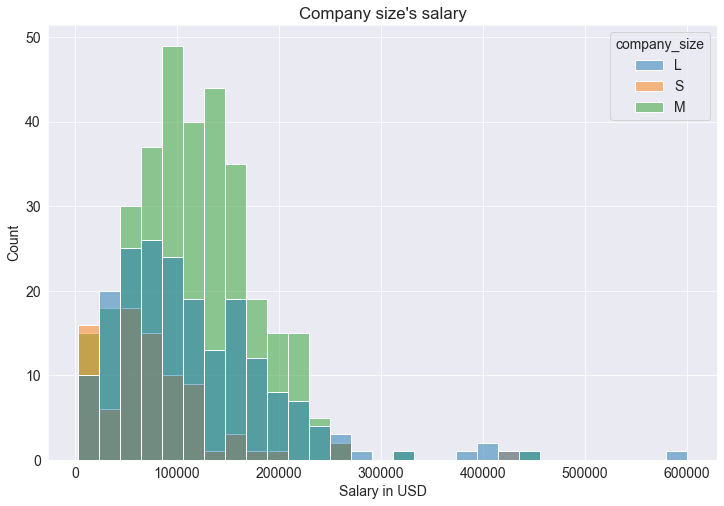

```python
plt.figure(figsize=(12,8))
plt.title('Company size\'s salary')
plt.xlabel('Salary in USD')
plt.ylabel('Count')
sns.histplot(x=ds_job_sal_df.salary_in_usd,hue=ds_job_sal_df.company_size);
```

Large companies pay higher salaries compared to Meduims. Only Large companies pays $600,000 which shows they can afford the most skilled and qualified in the Data science field. Small & Medium companies are still able within the the range of $400,000 below.

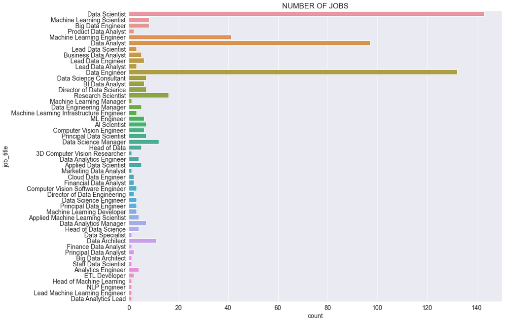

```python
plt.figure(figsize=(15,12))
plt.title('NUMBER OF JOBS')
plt.xlabel(None)
sns.countplot(y=ds_job_sal_df.job_title);
```

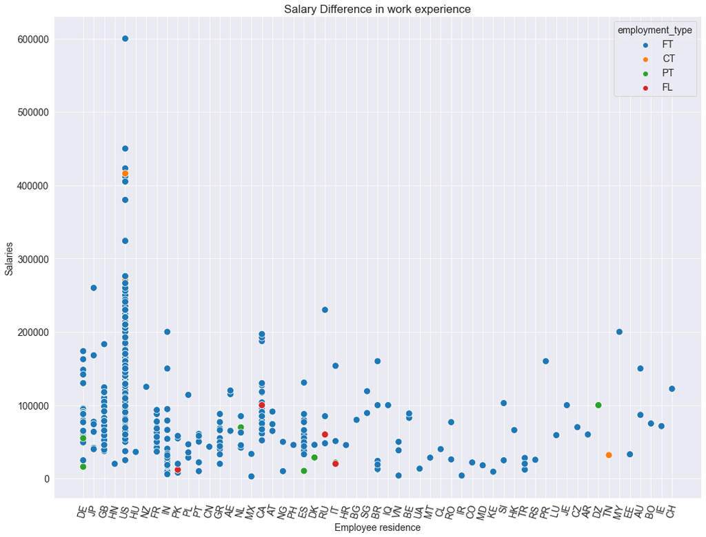

```python
plt.figure(figsize=(17,13))
plt.title('Salary Difference in work experience')
plt.xlabel('Employee residence')
plt.ylabel('Salaries')
plt.xticks(rotation=75)
sns.scatterplot(x=ds_job_sal_df.employee_residence, y=ds_job_sal_df.salary_in_usd, hue=ds_job_sal_df.employment_type, s=100);
```

The US as the highest FT employed type with a higher salary earnings unlike the rest of them which shows the marginlisation in salry earnings and effects of other currencies to the Dollar.

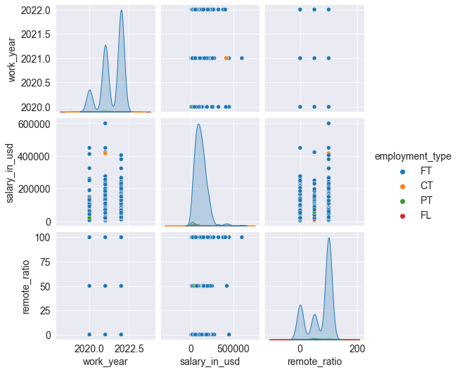

```python
plt.figure(figsize=(16,14))
sns.pairplot(ds_job_sal_df,hue='employment_type')
```

```python
ds_job_sal_df['job_branch']=ds_job_sal_df['job_title']
ds_job_sal_df
```

[output not shown]

```python
ds_job_sal_df
```

|  | work_year | experience_level | employment_type | job_title | salary_currency | salary_in_usd | employee_residence | remote_ratio | company_location | company_size | job_branch |
| --- | --- | --- | --- | --- | --- | --- | --- | --- | --- | --- | --- |
| 0 | 2020 | MI | FT | Data Scientist | EUR | 79833 | DE | 0 | DE | L | Data Scientist |
| 1 | 2020 | SE | FT | Machine Learning Scientist | USD | 260000 | JP | 0 | JP | S | Machine Learning Scientist |
| 2 | 2020 | SE | FT | Big Data Engineer | GBP | 109024 | GB | 50 | GB | M | Big Data Engineer |
| 3 | 2020 | MI | FT | Product Data Analyst | USD | 20000 | HN | 0 | HN | S | Product Data Analyst |
| 4 | 2020 | SE | FT | Machine Learning Engineer | USD | 150000 | US | 50 | US | L | Machine Learning Engineer |
| ... | ... | ... | ... | ... | ... | ... | ... | ... | ... | ... | ... |
| 602 | 2022 | SE | FT | Data Engineer | USD | 154000 | US | 100 | US | M | Data Engineer |
| 603 | 2022 | SE | FT | Data Engineer | USD | 126000 | US | 100 | US | M | Data Engineer |
| 604 | 2022 | SE | FT | Data Analyst | USD | 129000 | US | 0 | US | M | Data Analyst |
| 605 | 2022 | SE | FT | Data Analyst | USD | 150000 | US | 100 | US | M | Data Analyst |
| 606 | 2022 | MI | FT | AI Scientist | USD | 200000 | IN | 100 | US | L | AI Scientist |

607 rows × 11 columns

## EXPLORATIVE ANALYSIS

#### Q1:what is the salaries of Job branch with in respect to their Employment type?

```python
ds_job_sal_df['job_branch'].replace(['Data Scientist',
                                    'Research Scientist',
                                    'Data Science Manager',
                                    'Machine Learning Scientist',
                                    'Principal Data Scientist',
                                    'AI Scientist',
                                    'Data Science Consultant',
                                    'Director of Data Science',
                                    'Applied Data Scientist',
                                    'Applied Machine Learning Scientist',
                                    'Head of Data Science',
                                    'Lead Data Scientist',
                                    'Data Specialist',
                                    'Staff Data Scientist',
                                    'Machine Learning Manager'],'Data Science related jobs',inplace=True)
```

```python
ds_job_sal_df.job_branch.value_counts()
```

```
Data Science related jobs                   226
Data Engineer                               132
Data Analyst                                 97
Machine Learning Engineer                    41
Data Architect                               11
Big Data Engineer                             8
Data Analytics Manager                        7
BI Data Analyst                               6
Computer Vision Engineer                      6
ML Engineer                                   6
Lead Data Engineer                            6
Data Engineering Manager                      5
Head of Data                                  5
Business Data Analyst                         5
Analytics Engineer                            4
Data Analytics Engineer                       4
Machine Learning Infrastructure Engineer      3
Machine Learning Developer                    3
Lead Data Analyst                             3
Computer Vision Software Engineer             3
Data Science Engineer                         3
Principal Data Engineer                       3
Principal Data Analyst                        2
ETL Developer                                 2
Cloud Data Engineer                           2
Director of Data Engineering                  2
Financial Data Analyst                        2
Product Data Analyst                          2
Finance Data Analyst                          1
Marketing Data Analyst                        1
Big Data Architect                            1
3D Computer Vision Researcher                 1
Head of Machine Learning                      1
NLP Engineer                                  1
Lead Machine Learning Engineer                1
Data Analytics Lead                           1
Name: job_branch, dtype: int64
```

```python
ds_job_sal_df['job_branch'].replace(['Data Analyst',
                                    'Data Analytics Manager',
                                    'BI Data Analyst',
                                    'Head of Data',
                                    'Business Data Analyst',
                                    'Lead Data Analyst',
                                    'Financial Data Analyst',
                                    'Product Data Analyst',
                                    'Principal Data Analyst',
                                    'Marketing Data Analyst',
                                    'Finance Data Analyst',
                                    '3D Computer Vision Researcher','Data Analytics Lead'],'Data Analysis related jobs',inplace=True)
```

```python
ds_job_sal_df.job_branch.value_counts()
```

[output not shown]

```python
ds_job_sal_df['job_branch'].replace(['Lead Machine Learning Engineer',
                                    'NLP Engineer',
                                    'Head of Machine Learning',
                                    'Big Data Architect',
                                    'Director of Data Engineering',
                                    'Cloud Data Engineer',
                                    'ETL Developer',
                                    'Principal Data Engineer',
                                    'Data Science Engineer',
                                    'Computer Vision Software Engineer',
                                    'Machine Learning Developer',
                                    'Machine Learning Infrastructure Engineer',
                                    'Data Analytics Engineer',
                                    'Analytics Engineer',
                                    'Data Engineering Manager',
                                    'Lead Data Engineer',
                                    'ML Engineer',
                                    'Computer Vision Engineer',
                                    'Big Data Engineer',
                                    'Data Architect',
                                    'Machine Learning Engineer',
                                    'Data Engineer'],'Data Engineering related jobs',inplace=True)
```

```python
ds_job_sal_df.job_branch.value_counts()
```

```
Data Engineering related jobs    248
Data Science related jobs        226
Data Analysis related jobs       133
Name: job_branch, dtype: int64
```

```python
ds_job_sal_df.groupby('employment_type').mean()['salary_in_usd'].value_counts()
```

```
184575.000000    1
48000.000000     1
113468.073129    1
33070.500000     1
Name: salary_in_usd, dtype: int64
```

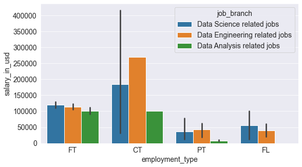

```python
sns.barplot(x=ds_job_sal_df.employment_type,y=ds_job_sal_df.salary_in_usd,hue=ds_job_sal_df.job_branch,data=ds_job_sal_df);
```

As noticed Data science has a higher earning for FT & FL employees, while Data engineering has a higher earing for CT and PT which shows data engineers prefer being employed using contracts and part time working schedule due to the nature of their job,while Data Science are employed full time or freelancing.

#### Q2: Which Employment type earns more?,and what is the average salaries earned?

```python
avg_sal_csize = ds_job_sal_df.groupby('employment_type').mean()['salary_in_usd'].sort_values(ascending=False)
avg_sal_csize
```

```
employment_type
CT    184575.000000
FT    113468.073129
FL     48000.000000
PT     33070.500000
Name: salary_in_usd, dtype: float64
```

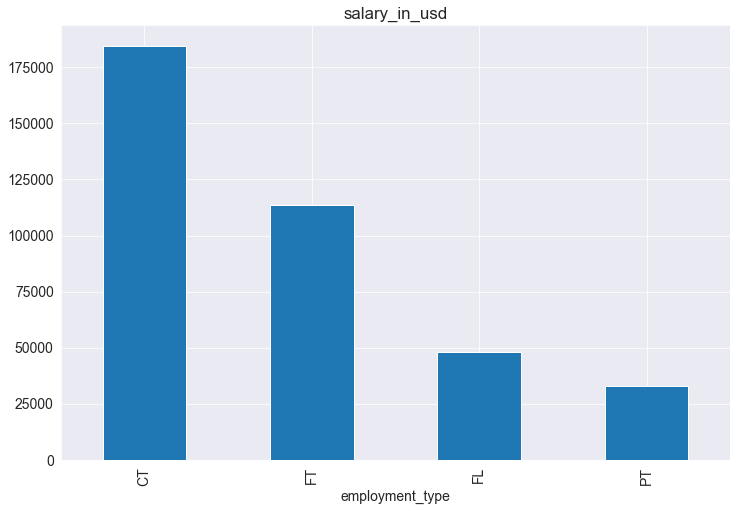

```python
avg_sal_csize.plot(kind='bar',subplots=True,figsize=(12,8));
```

CT earns more since contract jobs are extremely tedious with a time frame to finish compared to others

#### Q3: where do the most experienced data scientist reside?

```python
most_experienced=ds_job_sal_df[['experience_level','employee_residence']].value_counts()
most_experienced
```

```
experience_level  employee_residence
SE                US                    211
MI                US                     77
                  GB                     30
EN                US                     29
EX                US                     15
                                       ...
MI                CL                      1
                  CH                      1
                  BR                      1
                  BO                      1
SE                VN                      1
Length: 103, dtype: int64
```

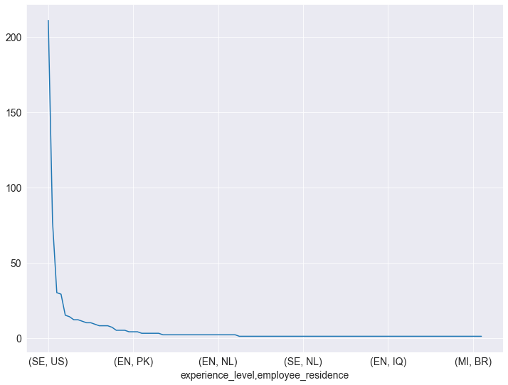

```python
most_experienced.plot(x='experience_level',figsize=(12,9),grid=True);
```

the US dominates the data science as of today with a lot of Skilled and well qualoified employees

#### Q4: - what are highest paying jobs in Data science?

```python
highest_paid=ds_job_sal_df.nlargest(n=10,columns=['salary_in_usd'])[['job_title','salary_in_usd']]
highest_paid
```

|  | job_title | salary_in_usd |
| --- | --- | --- |
| 252 | Principal Data Engineer | 600000 |
| 33 | Research Scientist | 450000 |
| 97 | Financial Data Analyst | 450000 |
| 157 | Applied Machine Learning Scientist | 423000 |
| 225 | Principal Data Scientist | 416000 |
| 63 | Data Scientist | 412000 |
| 523 | Data Analytics Lead | 405000 |
| 519 | Applied Data Scientist | 380000 |
| 25 | Director of Data Science | 325000 |
| 482 | Data Engineer | 324000 |

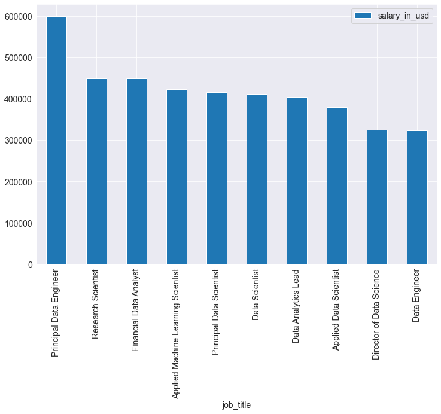

```python
highest_paid.plot(x='job_title',kind='bar',figsize=(12,8));
```

The Principal Data Engineer earns the highest salary in this survey.

```python
ds_job_sal_df
```

|  | work_year | experience_level | employment_type | job_title | salary_currency | salary_in_usd | employee_residence | remote_ratio | company_location | company_size | job_branch |
| --- | --- | --- | --- | --- | --- | --- | --- | --- | --- | --- | --- |
| 0 | 2020 | MI | FT | Data Scientist | EUR | 79833 | DE | 0 | DE | L | Data Science related jobs |
| 1 | 2020 | SE | FT | Machine Learning Scientist | USD | 260000 | JP | 0 | JP | S | Data Science related jobs |
| 2 | 2020 | SE | FT | Big Data Engineer | GBP | 109024 | GB | 50 | GB | M | Data Engineering related jobs |
| 3 | 2020 | MI | FT | Product Data Analyst | USD | 20000 | HN | 0 | HN | S | Data Analysis related jobs |
| 4 | 2020 | SE | FT | Machine Learning Engineer | USD | 150000 | US | 50 | US | L | Data Engineering related jobs |
| ... | ... | ... | ... | ... | ... | ... | ... | ... | ... | ... | ... |
| 602 | 2022 | SE | FT | Data Engineer | USD | 154000 | US | 100 | US | M | Data Engineering related jobs |
| 603 | 2022 | SE | FT | Data Engineer | USD | 126000 | US | 100 | US | M | Data Engineering related jobs |
| 604 | 2022 | SE | FT | Data Analyst | USD | 129000 | US | 0 | US | M | Data Analysis related jobs |
| 605 | 2022 | SE | FT | Data Analyst | USD | 150000 | US | 100 | US | M | Data Analysis related jobs |
| 606 | 2022 | MI | FT | AI Scientist | USD | 200000 | IN | 100 | US | L | Data Science related jobs |

607 rows × 11 columns

#### Q5: Where to look for jobs based on higher Experience level with an expected maximum salary?

```python
max_sal_job=ds_job_sal_df[['employment_type','experience_level','company_location']].value_counts()
max_sal_job
```

```
employment_type  experience_level  company_location
FT               SE                US                  216
                 MI                US                   87
                                   GB                   30
                 EN                US                   28
                 EX                US                   15
                                                      ...
                 MI                BE                    1
                                   AU                    1
                                   AE                    1
                 EX                PL                    1
PT               MI                NL                    1
Length: 106, dtype: int64
```

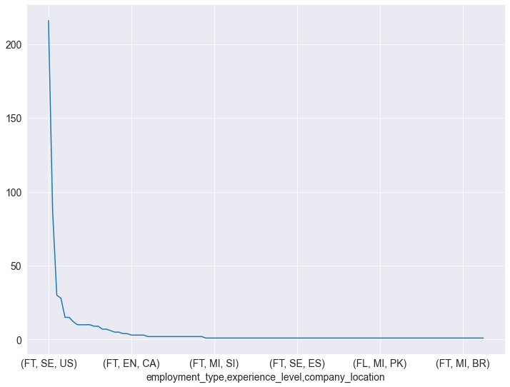

```python
max_sal_job.plot(x='experience_level',figsize=(12,9),grid=True);
```

It is no suprise the US Dominates this too as one most populous country with the Largest data network.

## INFERENCES AND CONCLUSION

##### Based on the survey it is noticed the US dominates the Data science industry.

##### CT employees earns while pt earns the least.

##### Data scientist /engineers/analyst are demanded more in the indusrtry.

##### The higher your experience level ,the higher your salary